# IMT 573 - Final Examination

Points: 100

Name: Andrea Rocha

### Instructions

This is a take-home final examination. You may use your computer, books/articles, notes, course materials, etc., but all work must be your own! Please review the course policy on AI-based learning tools. References must be appropriately cited. Please justify your answers and show all work; a complete argument must be presented to obtain full credit. Before beginning this exam, please ensure you have access to data programming environments used in the course; this can be on your own personal computer or on shared infrastructure hosted by the university.

1. Download the exam template notebook file from Canvas. Open exam notebook and supply your solutions to the exam by editing the notebook.
2. Be sure the exam contains your full name.
3. Be sure to include well-documented (e.g. commented) code chucks, figures, and clearly written text chunk explanations as necessary. Any figures should be clearly labeled and appropriately referenced within the text. Be sure that each visualization adds value to your written explanation; avoid redundancy -- you do not need four different visualizations of the same pattern.
4. **Collaboration is not allowed on this exam. You may only speak with the course instructor about this material.**
5. All materials and resources that you use (with the exception of lecture slides) must be appropriately referenced within your assignment.
6. Remember partial credit will be awarded for each question for which a serious attempt at finding an answer has been shown. Students are **strongly** encouraged to attempt each question and to document their reasoning process even if they cannot find the correct answer. If you would like to include code to show this process, but it does not run without errors, you can do so by commenting out that code.
7. When you have completed the assignment and have **checked** that your code both runs in the Console and compiles correctly rename the file to `YourLastName_YourFirstName.ipynb`, and submit BOTH your HTML and notebook files on Canvas.

### Statement of Compliance

You **must** include the a "signed" Statement of Compliance in your submission. The Compliance Statement is found below. You must include this text, word-for-word, in your final exam submission. Adding your name indicates you have read the statement and agree to its terms. Failure to do so will result in your exam **not** being accepted.

**Statement of Compliance**

I affirm that I have had no conversation regarding this exam with any persons other than the instructor. Further, I certify that the attached work represents my own thinking. Any information, concepts, or words that originate from other sources are cited in accordance with University of Washington guidelines as published in the Academic Code (available on the course website). I am aware of the serious consequences that result from improper discussions with others or from the improper citation of work that is not my own.

Andrea Rocha

11/28/2025

For this assignment, you'll need (at least) the following packages. If the package does not load, be sure it is properly installed.

```python
import pandas as pd
import numpy as np
import matplotlib.pyplot as plt
import seaborn as sns
import statsmodels.api as sm
```

### Problem 1

Points: 20

In this problem we will use data on infidelity, known as the Fair's Affairs dataset. The `Affairs` dataset is available as part of the `datasets` package in`statsmodels`. This data comes from a survey conducted by Psychology Today in 1969, see Greene (2003) and Fair (1978) for more information.

The dataset contains various self-reported characteristics of 6366 participants, including how often the respondent engaged in extramarital sexual intercourse during the past year, as well as their gender, age, year married, whether they had children, their religiousness (on a 5-point scale, from 1=anti to 5=very), education, occupation (Hillingshead 7-point classification with reverse numbering), and a numeric self-rating of their marriage (from 1=very unhappy to 5=very happy).

(a) Describe the participants. Use descriptive, summarization, and exploratory techniques to describe the participants in the study. Tell us the average/mean of children count ? What is the average age of respondents? In your response comment on any ethical and privacy concerns you have with this dataset.

**A**) After conducting an exploratory analysis on the participants from this study, I know that the average count of children is 1.39 and that the average age of the respondents are 29 years old. I also know that the max age of respondents is 42 and the minimum age was 17.5. On average, the respondents from this survey have been married for 9 years with a self-rating of 4.10 on their marriage meaning that the average participant from this survey would be considered happy in their marriage. The average occurance of affairs from the respondents was 0.7 and ~32.24% of total respondent participants did engage in an affair. This brings up ethical and privacy concerns for me regarding the data and the participants. Was there privacy when the survey was being taken? I.e., spouse not in the same room or taking the same survey. The lack of privacy could affect or skew the data integrity of the results because participants could be swayed to answer untruthfully. On this same notion, because these metrics were self-rated; the scale in which someone decides may differ either substaintially or possibily very little from each other making it also difficult to asses the accuracy of the data. But particularly on the affairs metric, is it measured by "how often" they engaged in extramarital sexual intercourse or "time spent"? Either way, this can be seen as an invasion to privacy because an affair would be considered unethical and immoral in normative ethics, so is it ethical to be asking people to divulge this information?

```python
#code part of notebook
affairs = sm.datasets.fair.load_pandas().data
print(sm.datasets.fair.NOTE)
```

```
::

    Number of observations: 6366
    Number of variables: 9
    Variable name definitions:

        rate_marriage   : How rate marriage, 1 = very poor, 2 = poor, 3 = fair,
                        4 = good, 5 = very good
        age             : Age
        yrs_married     : No. years married. Interval approximations. See
                        original paper for detailed explanation.
        children        : No. children
        religious       : How relgious, 1 = not, 2 = mildly, 3 = fairly,
                        4 = strongly
        educ            : Level of education, 9 = grade school, 12 = high
                        school, 14 = some college, 16 = college graduate,
                        17 = some graduate school, 20 = advanced degree
        occupation      : 1 = student, 2 = farming, agriculture; semi-skilled,
                        or unskilled worker; 3 = white-colloar; 4 = teacher
                        counselor social worker, nurse; artist, writers;
                        technician, skilled worker, 5 = managerial,
                        administrative, business, 6 = professional with
                        advanced degree
        occupation_husb : Husband's occupation. Same as occupation.
        affairs         : measure of time spent in extramarital affairs

    See the original paper for more details.
```

```python
#inspecting data shape
affairs.shape
```

```
(6366, 9)
```

```python
#by using the describe method, can get the mean/ average of ages and count of children - part a
affairs.describe()
```

|  | rate_marriage | age | yrs_married | children | religious | educ | occupation | occupation_husb | affairs |
| --- | --- | --- | --- | --- | --- | --- | --- | --- | --- |
| count | 6366.000000 | 6366.000000 | 6366.000000 | 6366.000000 | 6366.000000 | 6366.000000 | 6366.000000 | 6366.000000 | 6366.000000 |
| mean | 4.109645 | 29.082862 | 9.009425 | 1.396874 | 2.426170 | 14.209865 | 3.424128 | 3.850141 | 0.705374 |
| std | 0.961430 | 6.847882 | 7.280120 | 1.433471 | 0.878369 | 2.178003 | 0.942399 | 1.346435 | 2.203374 |
| min | 1.000000 | 17.500000 | 0.500000 | 0.000000 | 1.000000 | 9.000000 | 1.000000 | 1.000000 | 0.000000 |
| 25% | 4.000000 | 22.000000 | 2.500000 | 0.000000 | 2.000000 | 12.000000 | 3.000000 | 3.000000 | 0.000000 |
| 50% | 4.000000 | 27.000000 | 6.000000 | 1.000000 | 2.000000 | 14.000000 | 3.000000 | 4.000000 | 0.000000 |
| 75% | 5.000000 | 32.000000 | 16.500000 | 2.000000 | 3.000000 | 16.000000 | 4.000000 | 5.000000 | 0.484848 |
| max | 5.000000 | 42.000000 | 23.000000 | 5.500000 | 4.000000 | 20.000000 | 6.000000 | 6.000000 | 57.599991 |

```python
#using .info() function to see if there is any non-null values and inspect dtypes
affairs.info()
```

```
<class 'pandas.core.frame.DataFrame'>
RangeIndex: 6366 entries, 0 to 6365
Data columns (total 9 columns):
 #   Column           Non-Null Count  Dtype
---  ------           --------------  -----
 0   rate_marriage    6366 non-null   float64
 1   age              6366 non-null   float64
 2   yrs_married      6366 non-null   float64
 3   children         6366 non-null   float64
 4   religious        6366 non-null   float64
 5   educ             6366 non-null   float64
 6   occupation       6366 non-null   float64
 7   occupation_husb  6366 non-null   float64
 8   affairs          6366 non-null   float64
dtypes: float64(9)
memory usage: 447.7 KB
```

```python
#seeing count for respondents who did have affairs
#2053/6366 * 100 = 32.24 - percentage of people did have affairs
(affairs['affairs'] != 0.0).sum()
```

```
np.int64(2053)
```

```python
#using the head but with 15 to see the first 15 rows to get a deeper inspect of data not just with 5 rows
affairs.head(15)
```

|  | rate_marriage | age | yrs_married | children | religious | educ | occupation | occupation_husb | affairs |
| --- | --- | --- | --- | --- | --- | --- | --- | --- | --- |
| 0 | 3.0 | 32.0 | 9.0 | 3.0 | 3.0 | 17.0 | 2.0 | 5.0 | 0.111111 |
| 1 | 3.0 | 27.0 | 13.0 | 3.0 | 1.0 | 14.0 | 3.0 | 4.0 | 3.230769 |
| 2 | 4.0 | 22.0 | 2.5 | 0.0 | 1.0 | 16.0 | 3.0 | 5.0 | 1.400000 |
| 3 | 4.0 | 37.0 | 16.5 | 4.0 | 3.0 | 16.0 | 5.0 | 5.0 | 0.727273 |
| 4 | 5.0 | 27.0 | 9.0 | 1.0 | 1.0 | 14.0 | 3.0 | 4.0 | 4.666666 |
| 5 | 4.0 | 27.0 | 9.0 | 0.0 | 2.0 | 14.0 | 3.0 | 4.0 | 4.666666 |
| 6 | 5.0 | 37.0 | 23.0 | 5.5 | 2.0 | 12.0 | 5.0 | 4.0 | 0.852174 |
| 7 | 5.0 | 37.0 | 23.0 | 5.5 | 2.0 | 12.0 | 2.0 | 3.0 | 1.826086 |
| 8 | 3.0 | 22.0 | 2.5 | 0.0 | 2.0 | 12.0 | 3.0 | 3.0 | 4.799999 |
| 9 | 3.0 | 27.0 | 6.0 | 0.0 | 1.0 | 16.0 | 3.0 | 5.0 | 1.333333 |
| 10 | 2.0 | 27.0 | 6.0 | 2.0 | 1.0 | 16.0 | 3.0 | 5.0 | 3.266665 |
| 11 | 5.0 | 27.0 | 6.0 | 2.0 | 3.0 | 14.0 | 3.0 | 5.0 | 2.041666 |
| 12 | 3.0 | 37.0 | 16.5 | 5.5 | 1.0 | 12.0 | 2.0 | 3.0 | 0.484848 |
| 13 | 5.0 | 27.0 | 6.0 | 0.0 | 2.0 | 14.0 | 3.0 | 2.0 | 2.000000 |
| 14 | 4.0 | 22.0 | 6.0 | 1.0 | 1.0 | 14.0 | 4.0 | 4.0 | 3.266665 |

```python
#using the tail but with 15 to see the last 15 rows to get a deeper inspect of data not just with 5 rows
affairs.tail(15)
```

|  | rate_marriage | age | yrs_married | children | religious | educ | occupation | occupation_husb | affairs |
| --- | --- | --- | --- | --- | --- | --- | --- | --- | --- |
| 6351 | 4.0 | 22.0 | 0.5 | 0.0 | 2.0 | 16.0 | 3.0 | 1.0 | 0.0 |
| 6352 | 5.0 | 42.0 | 23.0 | 2.0 | 4.0 | 12.0 | 3.0 | 2.0 | 0.0 |
| 6353 | 5.0 | 22.0 | 2.5 | 2.0 | 2.0 | 14.0 | 3.0 | 5.0 | 0.0 |
| 6354 | 5.0 | 42.0 | 23.0 | 4.0 | 4.0 | 12.0 | 3.0 | 5.0 | 0.0 |
| 6355 | 4.0 | 27.0 | 6.0 | 0.0 | 3.0 | 12.0 | 3.0 | 4.0 | 0.0 |
| 6356 | 5.0 | 32.0 | 13.0 | 3.0 | 3.0 | 12.0 | 3.0 | 5.0 | 0.0 |
| 6357 | 5.0 | 32.0 | 13.0 | 4.0 | 2.0 | 14.0 | 4.0 | 4.0 | 0.0 |
| 6358 | 3.0 | 27.0 | 6.0 | 2.0 | 4.0 | 14.0 | 3.0 | 1.0 | 0.0 |
| 6359 | 4.0 | 22.0 | 2.5 | 0.0 | 3.0 | 16.0 | 5.0 | 5.0 | 0.0 |
| 6360 | 5.0 | 22.0 | 2.5 | 0.0 | 2.0 | 14.0 | 3.0 | 3.0 | 0.0 |
| 6361 | 5.0 | 32.0 | 13.0 | 2.0 | 3.0 | 17.0 | 4.0 | 3.0 | 0.0 |
| 6362 | 4.0 | 32.0 | 13.0 | 1.0 | 1.0 | 16.0 | 5.0 | 5.0 | 0.0 |
| 6363 | 5.0 | 22.0 | 2.5 | 0.0 | 2.0 | 14.0 | 3.0 | 1.0 | 0.0 |
| 6364 | 5.0 | 32.0 | 6.0 | 1.0 | 3.0 | 14.0 | 3.0 | 4.0 | 0.0 |
| 6365 | 4.0 | 22.0 | 2.5 | 0.0 | 2.0 | 16.0 | 2.0 | 4.0 | 0.0 |

(b) Suppose we want to explore the characteristics of participants who engage in extramarital sexual intercourse (i.e. affairs). Instead of modeling the number of affairs, consider the binary outcome - had an affair versus didn't have an affair. Create a new variable to capture this response variable of interest. What might the advantages and disadvantages of this approach to modeling the data be in this context?

**1B)** Some advantages into using a binary outcome approach like this is it easily splits your data into yes or no categories for a specific variable which can be useful for quick overviews and basic analysis like obtaining counts, grouping other variables together like had_affair and religion. It can also simplify creating data visualizations having these categories split into a yes or no. However, some disadvantages to this approach is it can disreagrd other nuances to your data that isn't easily seperated to yes or no categories or it oversimplifies data that is meant to be complex. For example, in this context, if I am looking at the data that is had an affair, that was converted into a value of "1" taking away the actual measurement of time/ frequency. When we are trying to see what other variables are creating a possible relationship, knowing exact measurements can create a stronger relationship to that varaible rather than just a one off e.g., someone who had an affair once vs someone who repeatedly had affairs and the relationship with children; having children or not having children could be a factor for number of occurances. Or how that can affect how the marriage rate is rated, is someone who often has affairs happy in their marriage or not? We can get an overview with the yes or no category, but having the data in the original form (in this context) would allow for a deeper dive in exploratory data analysis.

```python
#creating a copy of the df to store new variable for good data practice
affairs_df = affairs.copy()
```

```python
#new variable that captures response variable of interest and converting as an int
affairs_df['had_affair'] = (affairs['affairs'] > 0.0).astype(int)
```

```python
#double checking to see affairs properly stored into right variable
affairs_df
```

|  | rate_marriage | age | yrs_married | children | religious | educ | occupation | occupation_husb | affairs | had_affair |
| --- | --- | --- | --- | --- | --- | --- | --- | --- | --- | --- |
| 0 | 3.0 | 32.0 | 9.0 | 3.0 | 3.0 | 17.0 | 2.0 | 5.0 | 0.111111 | 1 |
| 1 | 3.0 | 27.0 | 13.0 | 3.0 | 1.0 | 14.0 | 3.0 | 4.0 | 3.230769 | 1 |
| 2 | 4.0 | 22.0 | 2.5 | 0.0 | 1.0 | 16.0 | 3.0 | 5.0 | 1.400000 | 1 |
| 3 | 4.0 | 37.0 | 16.5 | 4.0 | 3.0 | 16.0 | 5.0 | 5.0 | 0.727273 | 1 |
| 4 | 5.0 | 27.0 | 9.0 | 1.0 | 1.0 | 14.0 | 3.0 | 4.0 | 4.666666 | 1 |
| ... | ... | ... | ... | ... | ... | ... | ... | ... | ... | ... |
| 6361 | 5.0 | 32.0 | 13.0 | 2.0 | 3.0 | 17.0 | 4.0 | 3.0 | 0.000000 | 0 |
| 6362 | 4.0 | 32.0 | 13.0 | 1.0 | 1.0 | 16.0 | 5.0 | 5.0 | 0.000000 | 0 |
| 6363 | 5.0 | 22.0 | 2.5 | 0.0 | 2.0 | 14.0 | 3.0 | 1.0 | 0.000000 | 0 |
| 6364 | 5.0 | 32.0 | 6.0 | 1.0 | 3.0 | 14.0 | 3.0 | 4.0 | 0.000000 | 0 |
| 6365 | 4.0 | 22.0 | 2.5 | 0.0 | 2.0 | 16.0 | 2.0 | 4.0 | 0.000000 | 0 |

6366 rows × 10 columns

(c) Use an appropriate regression model to explore the relationship between having an affair (binary) and other personal characteristics. Comment on which covariates seem to be predictive of having an affair and which do not.

**1C)** In problem set 7 4b, I used gen ai to help me understand what my results summary were and the statistical significance, it was from that that I was able to understand that smaller p-values indicate a statistical significance with the variables. Hence the variables that seem to indicate a relationship with having an affair or not are age, years married, and religion. Because of the small p-values, these variables are statistically significant in this analysis and whether or not someone has children and their education do not seem to be predictive variables of whether or not someone has an affair.

```python
X_a = affairs_df[['rate_marriage','age', 'yrs_married', 'children', 'religious', 'educ']]
y_a = affairs_df['had_affair']
```

```python
X_with_const = sm.add_constant(X_a)
```

```python
model = sm.Logit(y_a, X_with_const).fit()
model.summary()
```

```
Optimization terminated successfully.
         Current function value: 0.547174
         Iterations 6
```

Logit Regression Results

| Dep. Variable: | had_affair | No. Observations: | 6366 |
| --- | --- | --- | --- |
| Model: | Logit | Df Residuals: | 6359 |
| Method: | MLE | Df Model: | 6 |
| Date: | Sun, 30 Nov 2025 | Pseudo R-squ.: | 0.1297 |
| Time: | 21:17:35 | Log-Likelihood: | -3483.3 |
| converged: | True | LL-Null: | -4002.5 |
| Covariance Type: | nonrobust | LLR p-value: | 4.345e-221 |

|  | coef | std err | z | P>\|z\| | [0.025 | 0.975] |
| --- | --- | --- | --- | --- | --- | --- |
| const | 3.8350 | 0.296 | 12.940 | 0.000 | 3.254 | 4.416 |
| rate_marriage | -0.7092 | 0.031 | -22.657 | 0.000 | -0.771 | -0.648 |
| age | -0.0580 | 0.010 | -5.662 | 0.000 | -0.078 | -0.038 |
| yrs_married | 0.1107 | 0.011 | 10.137 | 0.000 | 0.089 | 0.132 |
| children | -0.0102 | 0.032 | -0.322 | 0.747 | -0.072 | 0.052 |
| religious | -0.3722 | 0.035 | -10.740 | 0.000 | -0.440 | -0.304 |
| educ | -0.0121 | 0.014 | -0.846 | 0.397 | -0.040 | 0.016 |

(d) Use a model selection procedure to obtain a "best" fit model. Is the model different from the full model you fit in part (c)? Which variables are included in the "best" fit model? [Hint: stepwise selection]

**1D)** The variables that are included in the "best" fit model are: 'rate_marriage', 'age', 'yrs_married'. These variables are slightly different from the variables that were included in the model above and comparing the values, they are also different from the parameters value in the previous model. For this section on stepwise selection I used this as references https://scikit-learn.org/stable/modules/generated/sklearn.feature_selection.SequentialFeatureSelector.html#sklearn.feature_selection.SequentialFeatureSelector & https://www.geeksforgeeks.org/machine-learning/stepwise-regression-in-python/

```python
#importing appropriate packages
from sklearn.linear_model import LogisticRegression
from mlxtend.feature_selection import SequentialFeatureSelector
plt.style.use('seaborn-v0_8-whitegrid')
```

```python
X_a2 = affairs_df[['rate_marriage', 'age', 'yrs_married', 'children', 'religious', 'educ']]
y_a2 = affairs_df['had_affair']
```

```python
#stepwise regression
sfs = SequentialFeatureSelector(LogisticRegression(),
                                k_features= 3,
                                forward= False,
                                scoring= 'accuracy',
                                cv= 5)
sfs.fit(X_a2, y_a2)
```

```
SequentialFeatureSelector(estimator=LogisticRegression(), forward=False,
                          k_features=(3, 3), scoring='accuracy')
```

```python
s_features = list(sfs.k_feature_names_)
```

```python
X_bm = sm.add_constant(affairs_df[s_features])
b_model = sm.Logit(y_a2, X_bm).fit()
print(b_model.summary())
```

```
Optimization terminated successfully.
         Current function value: 0.556651
         Iterations 6
                           Logit Regression Results
==============================================================================
Dep. Variable:             had_affair   No. Observations:                 6366
Model:                          Logit   Df Residuals:                     6362
Method:                           MLE   Df Model:                            3
Date:                Sun, 30 Nov 2025   Pseudo R-squ.:                  0.1146
Time:                        22:21:48   Log-Likelihood:                -3543.6
converged:                       True   LL-Null:                       -4002.5
Covariance Type:            nonrobust   LLR p-value:                1.233e-198
=================================================================================
                    coef    std err          z      P>|z|      [0.025      0.975]
---------------------------------------------------------------------------------
const             3.0324      0.249     12.165      0.000       2.544       3.521
rate_marriage    -0.7273      0.031    -23.496      0.000      -0.788      -0.667
age              -0.0632      0.010     -6.487      0.000      -0.082      -0.044
yrs_married       0.1062      0.009     11.542      0.000       0.088       0.124
=================================================================================
```

(e) Interpret the model parameters using the model from part (d).

**1E)** Interpreting the model parameters from part 1D, as noted above, the variables that were included for this "best" fit model is rate_marriage, age, and years married. From the variables that were included all of them appear to be statistically significant because of the very small p-values = 0.000. The variable that seems to have a positive relationship to the variable of having had an affair is the number of years married; as the years increased so does the probability based on the positive coefficient. Because the other parameters are negative, as those increase, the probability of having an affair decreases. For example, as an individual gets older the liklihood of them having an affair decreases.

(f) Create an artificial test dataset where martial rating varies from 1 to 5 randomly and all other variables are set to their means. Use this artificial dataset as your test dataset to obtain predicted probabilities of having an affair for case in the test data. Interpret your results and use a visualization to support your interpretation.

**1F)** Interpreting my results from this artificial dataset, It is notable that the lower that a marriage was rated the probability of them having an affair is substainstially increased. Those indicating that they rated their marriage a 1 = very poor have a 79% probability of having an affair. And as the rate of the marriage increases the probability also decreases. My interpretation is supported in my visualization as you can see a clear linear relationship to increased probability with a low marriage rating and probability decreases the higher the marriage is rated.

```python
#creating the artificial dataset with means
s_features = ['rate_marriage', 'age', 'yrs_married', 'children', 'religious', 'educ']

test_data = pd.DataFrame({
    'rate_marriage': [1, 2, 3, 4, 5],
    'age': [affairs_df['age'].mean()] * 5,
    'yrs_married': [affairs_df['yrs_married'].mean()] * 5,
    'children': [affairs_df['children'].mean()] * 5,
    'religious': [affairs_df['religious'].mean()] * 5,
    'educ': [affairs_df['educ'].mean()] * 5})
```

```python
#adding constant and predictions from our artificial dataset
test_data_const = sm.add_constant(test_data, has_constant= 'add')
test_data['probability'] = b_model.predict(test_data_const)
print(test_data[['rate_marriage', 'probability']])
```

[output not shown]

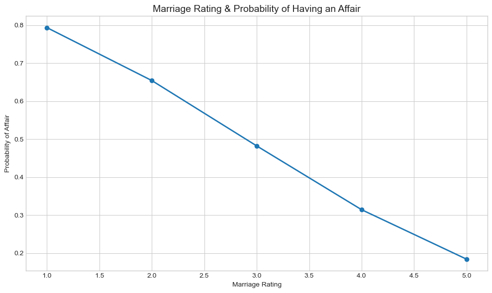

```python
#plotting
sns.set_style('whitegrid')
plt.figure(figsize = (10,6))
plt.plot(test_data['rate_marriage'], test_data['probability'], marker= 'o', linewidth= 2)
plt.xlabel('Marriage Rating')
plt.ylabel('Probability of Affair')
plt.title('Marriage Rating & Probability of Having an Affair', fontsize = 14)
plt.tight_layout()
plt.show()
```

(g) Reflect on your analysis in this problem. After completing all the parts of this analysis what remaining and additional ethical and privacy conerns do you have?

**1G)** After completing my analysis on this problem set 1, I have some doubts on my accuary of the models because originally when I ran the model I got the same variables with the same values. This didn't seem right so I changed the k_feature to only 3 variables and in doing so, the model parameter values also changed. I think some additional ethical concerns I have is that this model does not take into account the ethical principles and moral values that some people whole heartedly strive to uphold. Some people religous or not, would never harm their partner by cheating on them even if they are unhappy in their marriage. So this model discredits that and I also think this is not something that should be tried to be predicted.

### Problem 2

Points: 20

In this problem set, we will use some data from a sports context. The data is provided as part of the [Introduction to Statistial Learning with Applications in Python](https://www.statlearning.com/) textbook. It was taken from the StatLib library which is maintained at Carnegie Mellon University. The data provided is part of the data that was used in the 1988 ASA Graphics Section Poster Session. The salary data were originally from Sports Illustrated, April 20, 1987. The 1986 and career statistics were obtained from The 1987 Baseball Encyclopedia Update published by Collier Books, Macmillan Publishing Company, New York.

Following the directions below to load this data, `Hitters` directly from the `ISLP` python package. You may need to install the `ISLP` package before you can get started. In the Jupyter Hub you can open a terminal and use `pip install ISLP`. Next load the data as follows:

```python
from ISLP import load_data
Hitters = load_data('Hitters')
```

```python
Hitters.head()
```

|  | AtBat | Hits | HmRun | Runs | RBI | Walks | Years | CAtBat | CHits | CHmRun | CRuns | CRBI | CWalks | League | Division | PutOuts | Assists | Errors | Salary | NewLeague |
| --- | --- | --- | --- | --- | --- | --- | --- | --- | --- | --- | --- | --- | --- | --- | --- | --- | --- | --- | --- | --- |
| 0 | 293 | 66 | 1 | 30 | 29 | 14 | 1 | 293 | 66 | 1 | 30 | 29 | 14 | A | E | 446 | 33 | 20 | NaN | A |
| 1 | 315 | 81 | 7 | 24 | 38 | 39 | 14 | 3449 | 835 | 69 | 321 | 414 | 375 | N | W | 632 | 43 | 10 | 475.0 | N |
| 2 | 479 | 130 | 18 | 66 | 72 | 76 | 3 | 1624 | 457 | 63 | 224 | 266 | 263 | A | W | 880 | 82 | 14 | 480.0 | A |
| 3 | 496 | 141 | 20 | 65 | 78 | 37 | 11 | 5628 | 1575 | 225 | 828 | 838 | 354 | N | E | 200 | 11 | 3 | 500.0 | N |
| 4 | 321 | 87 | 10 | 39 | 42 | 30 | 2 | 396 | 101 | 12 | 48 | 46 | 33 | N | E | 805 | 40 | 4 | 91.5 | N |

```python
#getting to know/inspect this data
Hitters.tail()
```

|  | AtBat | Hits | HmRun | Runs | RBI | Walks | Years | CAtBat | CHits | CHmRun | CRuns | CRBI | CWalks | League | Division | PutOuts | Assists | Errors | Salary | NewLeague |
| --- | --- | --- | --- | --- | --- | --- | --- | --- | --- | --- | --- | --- | --- | --- | --- | --- | --- | --- | --- | --- |
| 317 | 497 | 127 | 7 | 65 | 48 | 37 | 5 | 2703 | 806 | 32 | 379 | 311 | 138 | N | E | 325 | 9 | 3 | 700.0 | N |
| 318 | 492 | 136 | 5 | 76 | 50 | 94 | 12 | 5511 | 1511 | 39 | 897 | 451 | 875 | A | E | 313 | 381 | 20 | 875.0 | A |
| 319 | 475 | 126 | 3 | 61 | 43 | 52 | 6 | 1700 | 433 | 7 | 217 | 93 | 146 | A | W | 37 | 113 | 7 | 385.0 | A |
| 320 | 573 | 144 | 9 | 85 | 60 | 78 | 8 | 3198 | 857 | 97 | 470 | 420 | 332 | A | E | 1314 | 131 | 12 | 960.0 | A |
| 321 | 631 | 170 | 9 | 77 | 44 | 31 | 11 | 4908 | 1457 | 30 | 775 | 357 | 249 | A | W | 408 | 4 | 3 | 1000.0 | A |

```python
Hitters.shape
```

```
(322, 20)
```

```python
Hitters.info()
```

```
<class 'pandas.core.frame.DataFrame'>
RangeIndex: 322 entries, 0 to 321
Data columns (total 20 columns):
 #   Column     Non-Null Count  Dtype
---  ------     --------------  -----
 0   AtBat      322 non-null    int64
 1   Hits       322 non-null    int64
 2   HmRun      322 non-null    int64
 3   Runs       322 non-null    int64
 4   RBI        322 non-null    int64
 5   Walks      322 non-null    int64
 6   Years      322 non-null    int64
 7   CAtBat     322 non-null    int64
 8   CHits      322 non-null    int64
 9   CHmRun     322 non-null    int64
 10  CRuns      322 non-null    int64
 11  CRBI       322 non-null    int64
 12  CWalks     322 non-null    int64
 13  League     322 non-null    category
 14  Division   322 non-null    category
 15  PutOuts    322 non-null    int64
 16  Assists    322 non-null    int64
 17  Errors     322 non-null    int64
 18  Salary     263 non-null    float64
 19  NewLeague  322 non-null    category
dtypes: category(3), float64(1), int64(16)
memory usage: 44.2 KB
```

```python
#inspecting the null values from the salary column
Hitters[Hitters['Salary'].isna()]
```

|  | AtBat | Hits | HmRun | Runs | RBI | Walks | Years | CAtBat | CHits | CHmRun | CRuns | CRBI | CWalks | League | Division | PutOuts | Assists | Errors | Salary | NewLeague |
| --- | --- | --- | --- | --- | --- | --- | --- | --- | --- | --- | --- | --- | --- | --- | --- | --- | --- | --- | --- | --- |
| 0 | 293 | 66 | 1 | 30 | 29 | 14 | 1 | 293 | 66 | 1 | 30 | 29 | 14 | A | E | 446 | 33 | 20 | NaN | A |
| 15 | 183 | 39 | 3 | 20 | 15 | 11 | 3 | 201 | 42 | 3 | 20 | 16 | 11 | A | W | 118 | 0 | 0 | NaN | A |
| 18 | 407 | 104 | 6 | 57 | 43 | 65 | 12 | 5233 | 1478 | 100 | 643 | 658 | 653 | A | W | 912 | 88 | 9 | NaN | A |
| 22 | 22 | 10 | 1 | 4 | 2 | 1 | 6 | 84 | 26 | 2 | 9 | 9 | 3 | A | W | 812 | 84 | 11 | NaN | A |
| 30 | 313 | 84 | 9 | 42 | 30 | 39 | 17 | 6890 | 1833 | 224 | 1033 | 864 | 1087 | A | W | 127 | 221 | 7 | NaN | A |
| 32 | 517 | 141 | 27 | 70 | 87 | 52 | 9 | 3571 | 994 | 215 | 545 | 652 | 337 | N | W | 1378 | 102 | 8 | NaN | N |
| 36 | 161 | 36 | 0 | 19 | 10 | 17 | 4 | 1053 | 244 | 3 | 156 | 86 | 107 | A | E | 70 | 149 | 12 | NaN | A |
| 38 | 346 | 98 | 5 | 31 | 53 | 30 | 16 | 5913 | 1615 | 235 | 784 | 901 | 560 | A | E | 0 | 0 | 0 | NaN | A |
| 39 | 241 | 61 | 1 | 34 | 12 | 14 | 1 | 241 | 61 | 1 | 34 | 12 | 14 | N | W | 166 | 172 | 10 | NaN | N |
| 41 | 216 | 54 | 0 | 21 | 18 | 15 | 18 | 7318 | 1926 | 46 | 796 | 627 | 483 | N | W | 103 | 84 | 5 | NaN | N |
| 42 | 200 | 57 | 6 | 23 | 14 | 14 | 9 | 2516 | 684 | 46 | 371 | 230 | 195 | N | W | 69 | 1 | 1 | NaN | N |
| 44 | 194 | 40 | 7 | 19 | 29 | 30 | 11 | 4183 | 1069 | 64 | 486 | 493 | 608 | A | E | 325 | 22 | 2 | NaN | A |
| 48 | 542 | 140 | 12 | 46 | 75 | 41 | 16 | 7099 | 2130 | 235 | 987 | 1089 | 431 | A | E | 697 | 61 | 9 | NaN | A |
| 52 | 19 | 7 | 0 | 1 | 2 | 1 | 4 | 41 | 13 | 1 | 3 | 4 | 4 | A | E | 0 | 0 | 0 | NaN | A |
| 57 | 235 | 61 | 3 | 24 | 39 | 21 | 14 | 3926 | 1029 | 35 | 441 | 401 | 333 | A | E | 425 | 43 | 4 | NaN | A |
| 64 | 24 | 3 | 0 | 1 | 0 | 2 | 3 | 159 | 28 | 0 | 20 | 12 | 9 | A | W | 80 | 4 | 0 | NaN | A |
| 66 | 191 | 37 | 4 | 12 | 17 | 14 | 4 | 773 | 163 | 16 | 61 | 74 | 52 | N | E | 391 | 38 | 8 | NaN | N |
| 69 | 419 | 113 | 1 | 44 | 27 | 44 | 12 | 4484 | 1231 | 32 | 612 | 344 | 422 | A | E | 211 | 2 | 1 | NaN | A |
| 71 | 138 | 31 | 8 | 18 | 21 | 38 | 3 | 244 | 53 | 12 | 33 | 32 | 55 | N | E | 244 | 21 | 4 | NaN | N |
| 77 | 195 | 55 | 5 | 24 | 33 | 30 | 8 | 1313 | 338 | 25 | 144 | 149 | 153 | N | E | 83 | 2 | 1 | NaN | N |
| 80 | 561 | 118 | 35 | 70 | 94 | 33 | 16 | 6677 | 1575 | 442 | 901 | 1210 | 608 | A | W | 463 | 32 | 8 | NaN | A |
| 83 | 227 | 46 | 7 | 23 | 20 | 12 | 5 | 1325 | 324 | 44 | 156 | 158 | 67 | A | W | 92 | 2 | 2 | NaN | A |
| 94 | 278 | 69 | 3 | 24 | 21 | 29 | 8 | 2079 | 565 | 32 | 258 | 192 | 162 | N | W | 142 | 210 | 10 | NaN | N |
| 97 | 277 | 71 | 2 | 27 | 29 | 14 | 15 | 5952 | 1647 | 60 | 753 | 596 | 259 | N | W | 360 | 32 | 5 | NaN | N |
| 101 | 524 | 132 | 9 | 69 | 47 | 54 | 2 | 972 | 260 | 14 | 123 | 92 | 90 | A | E | 212 | 327 | 20 | NaN | A |
| 103 | 395 | 106 | 16 | 48 | 56 | 35 | 10 | 2303 | 571 | 86 | 266 | 323 | 248 | A | E | 709 | 41 | 7 | NaN | A |
| 104 | 397 | 114 | 23 | 67 | 67 | 53 | 13 | 5589 | 1632 | 241 | 906 | 926 | 716 | A | E | 244 | 2 | 4 | NaN | A |
| 105 | 210 | 37 | 8 | 15 | 19 | 15 | 6 | 994 | 244 | 36 | 107 | 114 | 53 | A | E | 40 | 115 | 15 | NaN | A |
| 106 | 420 | 95 | 23 | 55 | 58 | 37 | 3 | 646 | 139 | 31 | 77 | 77 | 61 | N | W | 206 | 10 | 7 | NaN | N |
| 114 | 284 | 64 | 14 | 30 | 42 | 24 | 18 | 7023 | 1925 | 348 | 986 | 1239 | 666 | N | E | 96 | 4 | 4 | NaN | N |
| 125 | 315 | 59 | 16 | 45 | 36 | 58 | 13 | 4677 | 1051 | 268 | 681 | 782 | 697 | A | W | 0 | 0 | 0 | NaN | A |
| 138 | 284 | 69 | 1 | 33 | 18 | 25 | 5 | 1407 | 361 | 6 | 139 | 98 | 111 | A | E | 122 | 140 | 5 | NaN | N |
| 144 | 209 | 45 | 0 | 38 | 19 | 42 | 10 | 3859 | 916 | 23 | 557 | 279 | 478 | A | W | 132 | 205 | 5 | NaN | A |
| 150 | 225 | 61 | 5 | 32 | 26 | 26 | 11 | 1568 | 408 | 25 | 202 | 185 | 257 | A | W | 132 | 9 | 0 | NaN | A |
| 157 | 401 | 100 | 2 | 60 | 19 | 28 | 4 | 876 | 238 | 2 | 126 | 44 | 55 | N | E | 193 | 11 | 4 | NaN | N |
| 158 | 336 | 93 | 9 | 35 | 46 | 23 | 15 | 5779 | 1610 | 128 | 730 | 741 | 497 | A | W | 0 | 0 | 0 | NaN | A |
| 160 | 219 | 47 | 8 | 24 | 26 | 17 | 12 | 1188 | 286 | 23 | 100 | 125 | 63 | A | W | 260 | 58 | 4 | NaN | A |
| 169 | 249 | 69 | 6 | 32 | 19 | 20 | 4 | 702 | 209 | 10 | 97 | 48 | 44 | N | E | 103 | 8 | 2 | NaN | N |
| 171 | 212 | 54 | 13 | 28 | 44 | 18 | 2 | 233 | 59 | 13 | 31 | 46 | 20 | A | E | 243 | 23 | 5 | NaN | A |
| 173 | 161 | 43 | 4 | 17 | 26 | 22 | 3 | 707 | 179 | 21 | 77 | 99 | 76 | A | W | 300 | 12 | 2 | NaN | A |
| 197 | 166 | 34 | 0 | 20 | 13 | 17 | 1 | 166 | 34 | 0 | 20 | 13 | 17 | N | E | 64 | 119 | 9 | NaN | N |
| 199 | 508 | 146 | 8 | 80 | 44 | 46 | 9 | 3148 | 915 | 41 | 571 | 289 | 326 | A | W | 245 | 5 | 9 | NaN | A |
| 203 | 243 | 53 | 4 | 18 | 26 | 27 | 4 | 853 | 228 | 23 | 101 | 110 | 76 | N | E | 107 | 3 | 3 | NaN | N |
| 208 | 209 | 59 | 6 | 20 | 37 | 27 | 4 | 884 | 209 | 14 | 66 | 106 | 92 | N | E | 415 | 35 | 3 | NaN | N |
| 210 | 317 | 88 | 3 | 40 | 32 | 19 | 8 | 2543 | 715 | 28 | 269 | 270 | 118 | A | W | 220 | 16 | 4 | NaN | A |
| 225 | 330 | 76 | 12 | 35 | 41 | 47 | 4 | 1367 | 326 | 55 | 167 | 198 | 167 | N | W | 512 | 30 | 5 | NaN | N |
| 228 | 359 | 84 | 4 | 46 | 27 | 21 | 12 | 4992 | 1257 | 37 | 699 | 386 | 387 | N | W | 151 | 8 | 5 | NaN | N |
| 235 | 551 | 160 | 23 | 86 | 90 | 87 | 5 | 2235 | 602 | 75 | 278 | 328 | 273 | A | W | 1224 | 115 | 11 | NaN | A |
| 246 | 462 | 119 | 16 | 49 | 65 | 37 | 7 | 2131 | 583 | 69 | 244 | 288 | 150 | A | E | 866 | 65 | 6 | NaN | A |
| 250 | 33 | 6 | 0 | 2 | 4 | 7 | 1 | 33 | 6 | 0 | 2 | 4 | 7 | A | W | 205 | 5 | 4 | NaN | A |
| 253 | 186 | 44 | 7 | 28 | 16 | 11 | 1 | 186 | 44 | 7 | 28 | 16 | 11 | N | W | 99 | 3 | 1 | NaN | N |
| 254 | 307 | 80 | 1 | 42 | 36 | 29 | 7 | 2421 | 656 | 18 | 379 | 198 | 184 | A | W | 145 | 2 | 2 | NaN | A |
| 270 | 303 | 84 | 4 | 35 | 32 | 23 | 2 | 312 | 87 | 4 | 39 | 32 | 23 | N | W | 179 | 5 | 3 | NaN | N |
| 283 | 16 | 2 | 0 | 1 | 0 | 0 | 2 | 28 | 4 | 0 | 1 | 0 | 0 | A | E | 247 | 4 | 8 | NaN | A |
| 292 | 289 | 63 | 7 | 36 | 41 | 44 | 17 | 7402 | 1954 | 195 | 1115 | 919 | 1153 | A | W | 166 | 211 | 7 | NaN | A |
| 298 | 181 | 46 | 1 | 19 | 18 | 17 | 5 | 937 | 238 | 9 | 88 | 95 | 104 | A | E | 37 | 98 | 9 | NaN | A |
| 302 | 200 | 51 | 2 | 14 | 29 | 25 | 23 | 9778 | 2732 | 379 | 1272 | 1652 | 925 | N | W | 398 | 29 | 7 | NaN | N |
| 305 | 580 | 194 | 9 | 91 | 62 | 78 | 8 | 3372 | 1028 | 48 | 604 | 314 | 469 | N | E | 270 | 13 | 6 | NaN | N |
| 316 | 221 | 53 | 2 | 21 | 23 | 22 | 8 | 1063 | 283 | 15 | 107 | 124 | 106 | N | E | 325 | 58 | 6 | NaN | N |

```python
Hitters.describe()
```

|  | AtBat | Hits | HmRun | Runs | RBI | Walks | Years | CAtBat | CHits | CHmRun | CRuns | CRBI | CWalks | PutOuts | Assists | Errors | Salary |
| --- | --- | --- | --- | --- | --- | --- | --- | --- | --- | --- | --- | --- | --- | --- | --- | --- | --- |
| count | 322.000000 | 322.000000 | 322.000000 | 322.000000 | 322.000000 | 322.000000 | 322.000000 | 322.00000 | 322.000000 | 322.000000 | 322.000000 | 322.000000 | 322.000000 | 322.000000 | 322.000000 | 322.000000 | 263.000000 |
| mean | 380.928571 | 101.024845 | 10.770186 | 50.909938 | 48.027950 | 38.742236 | 7.444099 | 2648.68323 | 717.571429 | 69.490683 | 358.795031 | 330.118012 | 260.239130 | 288.937888 | 106.913043 | 8.040373 | 535.925882 |
| std | 153.404981 | 46.454741 | 8.709037 | 26.024095 | 26.166895 | 21.639327 | 4.926087 | 2324.20587 | 654.472627 | 86.266061 | 334.105886 | 333.219617 | 267.058085 | 280.704614 | 136.854876 | 6.368359 | 451.118681 |
| min | 16.000000 | 1.000000 | 0.000000 | 0.000000 | 0.000000 | 0.000000 | 1.000000 | 19.00000 | 4.000000 | 0.000000 | 1.000000 | 0.000000 | 0.000000 | 0.000000 | 0.000000 | 0.000000 | 67.500000 |
| 25% | 255.250000 | 64.000000 | 4.000000 | 30.250000 | 28.000000 | 22.000000 | 4.000000 | 816.75000 | 209.000000 | 14.000000 | 100.250000 | 88.750000 | 67.250000 | 109.250000 | 7.000000 | 3.000000 | 190.000000 |
| 50% | 379.500000 | 96.000000 | 8.000000 | 48.000000 | 44.000000 | 35.000000 | 6.000000 | 1928.00000 | 508.000000 | 37.500000 | 247.000000 | 220.500000 | 170.500000 | 212.000000 | 39.500000 | 6.000000 | 425.000000 |
| 75% | 512.000000 | 137.000000 | 16.000000 | 69.000000 | 64.750000 | 53.000000 | 11.000000 | 3924.25000 | 1059.250000 | 90.000000 | 526.250000 | 426.250000 | 339.250000 | 325.000000 | 166.000000 | 11.000000 | 750.000000 |
| max | 687.000000 | 238.000000 | 40.000000 | 130.000000 | 121.000000 | 105.000000 | 24.000000 | 14053.00000 | 4256.000000 | 548.000000 | 2165.000000 | 1659.000000 | 1566.000000 | 1378.000000 | 492.000000 | 32.000000 | 2460.000000 |

(a) Develop your own question to address in this analysis. Your question should be specific and measurable, and it should be able to be addressed through a basic analysis of the `Hitters` dataset. Hint: you will need to get to know this dataset and the variables available to formulate an appropriate question.

**2A)** After inspecting the data in the cells above, I am curious about the relationship between the number of years and salary. My question is: Does an increase in the number of years reflect an increase in salary amount?

(b) Briefly summarize the dataset, describing what data exists and its basic properties. Comment on any issues that need to be resolved before you can proceed with your analysis.

**2B)** In the Hitters dataset, it is a fairly small dataset with only 322 rows of data with 20 variables that hold information regarding baseball statistics such as home runs, at bats, hits and leauge info. It also contains salary information which is also the only column that contains some missing data values and is in a float dtype. The rest of the dataset is primarly integers and a few category types used to describe the division, league, and new leaugue info. Because the question I am striving to answer in my analysis has to do with the salary in which we have missing values, I am going to be dropping those NaN values so I do not get any issues or errors.

```python
#dropping null values
hitters_df = Hitters.dropna().copy()
```

```python
hitters_df #dropped 59 rows
```

|  | AtBat | Hits | HmRun | Runs | RBI | Walks | Years | CAtBat | CHits | CHmRun | CRuns | CRBI | CWalks | League | Division | PutOuts | Assists | Errors | Salary | NewLeague |
| --- | --- | --- | --- | --- | --- | --- | --- | --- | --- | --- | --- | --- | --- | --- | --- | --- | --- | --- | --- | --- |
| 1 | 315 | 81 | 7 | 24 | 38 | 39 | 14 | 3449 | 835 | 69 | 321 | 414 | 375 | N | W | 632 | 43 | 10 | 475.0 | N |
| 2 | 479 | 130 | 18 | 66 | 72 | 76 | 3 | 1624 | 457 | 63 | 224 | 266 | 263 | A | W | 880 | 82 | 14 | 480.0 | A |
| 3 | 496 | 141 | 20 | 65 | 78 | 37 | 11 | 5628 | 1575 | 225 | 828 | 838 | 354 | N | E | 200 | 11 | 3 | 500.0 | N |
| 4 | 321 | 87 | 10 | 39 | 42 | 30 | 2 | 396 | 101 | 12 | 48 | 46 | 33 | N | E | 805 | 40 | 4 | 91.5 | N |
| 5 | 594 | 169 | 4 | 74 | 51 | 35 | 11 | 4408 | 1133 | 19 | 501 | 336 | 194 | A | W | 282 | 421 | 25 | 750.0 | A |
| ... | ... | ... | ... | ... | ... | ... | ... | ... | ... | ... | ... | ... | ... | ... | ... | ... | ... | ... | ... | ... |
| 317 | 497 | 127 | 7 | 65 | 48 | 37 | 5 | 2703 | 806 | 32 | 379 | 311 | 138 | N | E | 325 | 9 | 3 | 700.0 | N |
| 318 | 492 | 136 | 5 | 76 | 50 | 94 | 12 | 5511 | 1511 | 39 | 897 | 451 | 875 | A | E | 313 | 381 | 20 | 875.0 | A |
| 319 | 475 | 126 | 3 | 61 | 43 | 52 | 6 | 1700 | 433 | 7 | 217 | 93 | 146 | A | W | 37 | 113 | 7 | 385.0 | A |
| 320 | 573 | 144 | 9 | 85 | 60 | 78 | 8 | 3198 | 857 | 97 | 470 | 420 | 332 | A | E | 1314 | 131 | 12 | 960.0 | A |
| 321 | 631 | 170 | 9 | 77 | 44 | 31 | 11 | 4908 | 1457 | 30 | 775 | 357 | 249 | A | W | 408 | 4 | 3 | 1000.0 | A |

263 rows × 20 columns

(c) Use the dataset to provide empirical evidence that addressed your question from (a). Discuss your results. Provide at least two visualizations to support your story.

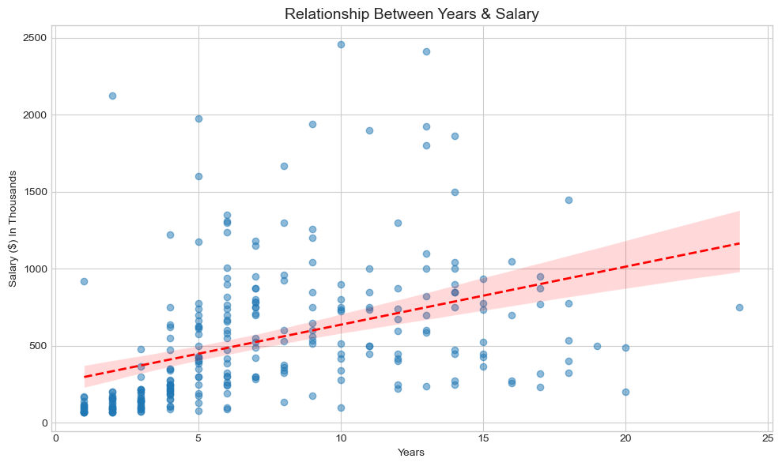

```python
#first visualization
sns.set_style('whitegrid')
plt.figure(figsize = (10,6))
sns.regplot(x= "Years", y="Salary", data = hitters_df,
            scatter_kws= {'alpha': 0.5},
            line_kws= {'color': 'red', 'linestyle': '--', 'linewidth': 2})
plt.xlabel('Years')
plt.ylabel('Salary ($) In Thousands')
plt.title('Relationship Between Years & Salary', fontsize = 14)
plt.tight_layout()
plt.show()
```

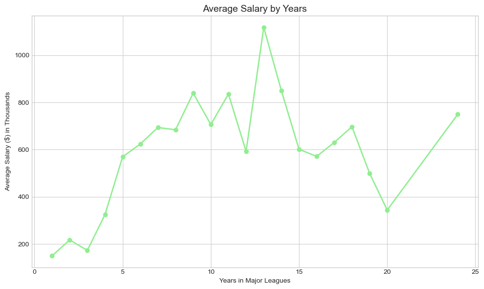

```python
#grouping by average to see what the relationship looks in this way
yearly_avgs = hitters_df.groupby('Years')['Salary'].mean().reset_index()

sns.set_style('whitegrid')
plt.figure(figsize = (10,6))
plt.plot(yearly_avgs['Years'], yearly_avgs['Salary'], marker= 'o', linewidth= 2, color= 'lightgreen')
plt.xlabel('Years in Major Leagues')
plt.ylabel("Average Salary ($) in Thousands")
plt.title("Average Salary by Years", fontsize = 14)
plt.tight_layout()
plt.show()
```

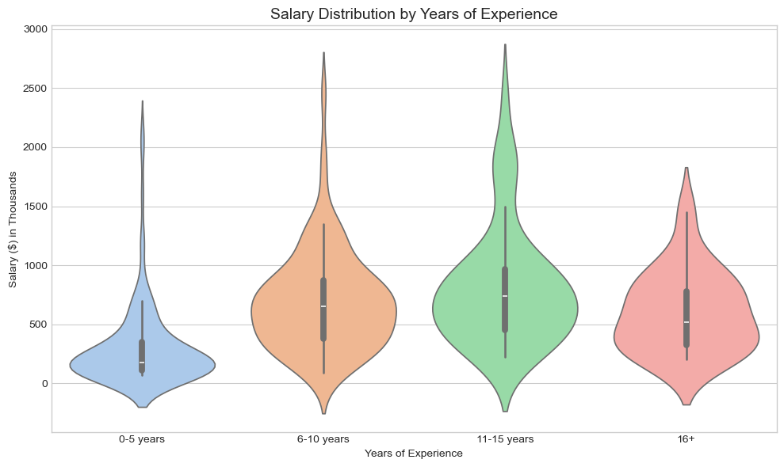

```python
#Reference from ps8 - creating groups with range for years
hitters_df['YearsGrouped'] = pd.cut(hitters_df['Years'],
                                    bins= [0, 5, 10, 15, 25],
                                    labels = ['0-5 years', '6-10 years', '11-15 years', '16+'])
sns.set_style('whitegrid')
plt.figure(figsize = (10,6))
sns.violinplot(data=hitters_df, x="YearsGrouped", y="Salary", palette= 'pastel', legend=False, hue="YearsGrouped")
plt.xlabel('Years of Experience')
plt.ylabel('Salary ($) in Thousands')
plt.title("Salary Distribution by Years of Experience", fontsize = 14)
plt.tight_layout()
plt.show()
```

(d) Comment the questions (and answers) in this analysis. Were you able to answer all of these questions? Are all questions well defined? Is the data good enough to answer all these?

### Problem 3

Points: 20

In this problem, we will use data available in [Machine Learning with R by Brett Lantz](https://subscription.packtpub.com/search?query=machine%20learning%20r). This data was available in the public domain and a few version exist online.

The data describe individual medical costs billed by health insurance. For each observation, there is information about:

- age: age of primary beneficiary of the insurance policy
- sex: the person's sex, measured here a binary gender
- bmi: body mass index, providing an understanding of body, weights that are relatively high or low relative to height, (kg / m ^ 2)
- children: number of children/dependents covered by health insurance
- smoker: smoking status of the primary beneficiary
- region: the beneficiary's residential area in the US, northeast, southeast, southwest, northwest.
- charges: medical costs billed by health insurance

In our analysis, we will be interested in the relationship between `charges` and the individual characteristics measured.

```python
df = pd.read_csv('insurance.csv')
df.head(15)
```

|  | age | sex | bmi | children | smoker | region | charges |
| --- | --- | --- | --- | --- | --- | --- | --- |
| 0 | 19 | female | 27.900 | 0 | yes | southwest | 16884.92400 |
| 1 | 18 | male | 33.770 | 1 | no | southeast | 1725.55230 |
| 2 | 28 | male | 33.000 | 3 | no | southeast | 4449.46200 |
| 3 | 33 | male | 22.705 | 0 | no | northwest | 21984.47061 |
| 4 | 32 | male | 28.880 | 0 | no | northwest | 3866.85520 |
| 5 | 31 | female | 25.740 | 0 | no | southeast | 3756.62160 |
| 6 | 46 | female | 33.440 | 1 | no | southeast | 8240.58960 |
| 7 | 37 | female | 27.740 | 3 | no | northwest | 7281.50560 |
| 8 | 37 | male | 29.830 | 2 | no | northeast | 6406.41070 |
| 9 | 60 | female | 25.840 | 0 | no | northwest | 28923.13692 |
| 10 | 25 | male | 26.220 | 0 | no | northeast | 2721.32080 |
| 11 | 62 | female | 26.290 | 0 | yes | southeast | 27808.72510 |
| 12 | 23 | male | 34.400 | 0 | no | southwest | 1826.84300 |
| 13 | 56 | female | 39.820 | 0 | no | southeast | 11090.71780 |
| 14 | 27 | male | 42.130 | 0 | yes | southeast | 39611.75770 |

```python
df.tail(15)
```

|  | age | sex | bmi | children | smoker | region | charges |
| --- | --- | --- | --- | --- | --- | --- | --- |
| 1323 | 42 | female | 40.370 | 2 | yes | southeast | 43896.37630 |
| 1324 | 31 | male | 25.935 | 1 | no | northwest | 4239.89265 |
| 1325 | 61 | male | 33.535 | 0 | no | northeast | 13143.33665 |
| 1326 | 42 | female | 32.870 | 0 | no | northeast | 7050.02130 |
| 1327 | 51 | male | 30.030 | 1 | no | southeast | 9377.90470 |
| 1328 | 23 | female | 24.225 | 2 | no | northeast | 22395.74424 |
| 1329 | 52 | male | 38.600 | 2 | no | southwest | 10325.20600 |
| 1330 | 57 | female | 25.740 | 2 | no | southeast | 12629.16560 |
| 1331 | 23 | female | 33.400 | 0 | no | southwest | 10795.93733 |
| 1332 | 52 | female | 44.700 | 3 | no | southwest | 11411.68500 |
| 1333 | 50 | male | 30.970 | 3 | no | northwest | 10600.54830 |
| 1334 | 18 | female | 31.920 | 0 | no | northeast | 2205.98080 |
| 1335 | 18 | female | 36.850 | 0 | no | southeast | 1629.83350 |
| 1336 | 21 | female | 25.800 | 0 | no | southwest | 2007.94500 |
| 1337 | 61 | female | 29.070 | 0 | yes | northwest | 29141.36030 |

```python
df.shape
```

```
(1338, 7)
```

In our analysis, we will be interested in the relationship between charges and the individual characteristics measured.

(a) Examine the bivariate relationships present in the data. Briefly discuss notable results.

**3A)** After examining the data and looking at the bivariate relationships with the individual characteristics some notable results is how individuals who smoke have significantly higher charges than someone who does not. Another notable relationship is bmi. Individuals with higher bmi scores appear to have higher charges than someone who does not. Lastly, the last notable relationship is age, it appears that the older that someone is, the larger the charges as well.

```python
df.info()
```

```
<class 'pandas.core.frame.DataFrame'>
RangeIndex: 1338 entries, 0 to 1337
Data columns (total 7 columns):
 #   Column    Non-Null Count  Dtype
---  ------    --------------  -----
 0   age       1338 non-null   int64
 1   sex       1338 non-null   object
 2   bmi       1338 non-null   float64
 3   children  1338 non-null   int64
 4   smoker    1338 non-null   object
 5   region    1338 non-null   object
 6   charges   1338 non-null   float64
dtypes: float64(2), int64(2), object(3)
memory usage: 73.3+ KB
```

```python
df.describe()
```

|  | age | bmi | children | charges |
| --- | --- | --- | --- | --- |
| count | 1338.000000 | 1338.000000 | 1338.000000 | 1338.000000 |
| mean | 39.207025 | 30.663397 | 1.094918 | 13270.422265 |
| std | 14.049960 | 6.098187 | 1.205493 | 12110.011237 |
| min | 18.000000 | 15.960000 | 0.000000 | 1121.873900 |
| 25% | 27.000000 | 26.296250 | 0.000000 | 4740.287150 |
| 50% | 39.000000 | 30.400000 | 1.000000 | 9382.033000 |
| 75% | 51.000000 | 34.693750 | 2.000000 | 16639.912515 |
| max | 64.000000 | 53.130000 | 5.000000 | 63770.428010 |

(b) Fit a multiple linear regression model. How much variance in the medical costs(charges) does this variable- bmi explain?

**3B)** After fitting a multiple linear regression model, I calculated the variance by subtracting the r-squared values from the r-squared value that included bmi as a predictor and then subtracting it from the r-squared values that did not include bmi as a predictor to get the numerical measure of how spread out the values were. The BMI variance I calculated was 0.025 which is equivalent to 2.5% which is a small percentage indicating a not so strong relationship as bmi being a predictor to medical costs aka weak relationship.

```python
from sklearn.linear_model import LinearRegression
```

```python
#defining categorical variables so I can convert
catg_vars = ['sex', 'smoker', 'region']
```

```python
#using get dummies like in ps8
dummy_df = pd.get_dummies(df, columns= catg_vars, drop_first= True)
dummy_df = dummy_df.astype(float)
```

```python
#checking my dummy_df
dummy_df
```

|  | age | bmi | children | charges | sex_male | smoker_yes | region_northwest | region_southeast | region_southwest |
| --- | --- | --- | --- | --- | --- | --- | --- | --- | --- |
| 0 | 19.0 | 27.900 | 0.0 | 16884.92400 | 0.0 | 1.0 | 0.0 | 0.0 | 1.0 |
| 1 | 18.0 | 33.770 | 1.0 | 1725.55230 | 1.0 | 0.0 | 0.0 | 1.0 | 0.0 |
| 2 | 28.0 | 33.000 | 3.0 | 4449.46200 | 1.0 | 0.0 | 0.0 | 1.0 | 0.0 |
| 3 | 33.0 | 22.705 | 0.0 | 21984.47061 | 1.0 | 0.0 | 1.0 | 0.0 | 0.0 |
| 4 | 32.0 | 28.880 | 0.0 | 3866.85520 | 1.0 | 0.0 | 1.0 | 0.0 | 0.0 |
| ... | ... | ... | ... | ... | ... | ... | ... | ... | ... |
| 1333 | 50.0 | 30.970 | 3.0 | 10600.54830 | 1.0 | 0.0 | 1.0 | 0.0 | 0.0 |
| 1334 | 18.0 | 31.920 | 0.0 | 2205.98080 | 0.0 | 0.0 | 0.0 | 0.0 | 0.0 |
| 1335 | 18.0 | 36.850 | 0.0 | 1629.83350 | 0.0 | 0.0 | 0.0 | 1.0 | 0.0 |
| 1336 | 21.0 | 25.800 | 0.0 | 2007.94500 | 0.0 | 0.0 | 0.0 | 0.0 | 1.0 |
| 1337 | 61.0 | 29.070 | 0.0 | 29141.36030 | 0.0 | 1.0 | 1.0 | 0.0 | 0.0 |

1338 rows × 9 columns

```python
#multiple predictors and charges as the response
prds = dummy_df[['age', 'bmi', 'children', 'sex_male', 'smoker_yes']].values
rsp = dummy_df['charges'].values
```

```python
bmi_model = LinearRegression()
bmi_model.fit(prds, rsp)
```

```
LinearRegression()
```

```python
#r-squared of all the predictors I decided to include
r_sqrd = bmi_model.score(prds, rsp)
print(r_sqrd)
```

```
0.7497225098709179
```

```python
#removing bmi as a predictor so I can calculate the change in the r-squares to see variance for bmi
prds_no_bmi = ['age', 'children', 'sex_male', 'smoker_yes']
prds_2 = dummy_df[prds_no_bmi]
```

```python
no_bmi_model = LinearRegression()
no_bmi_model.fit(prds_2, rsp)
```

```
LinearRegression()
```

```python
#r-squared of all predictors I decided to include minus the bmi
r_sqrd_2= no_bmi_model.score(prds_2, rsp)
print(r_sqrd_2)
```

```
0.7237495964252298
```

```python
#seeing variance for bmi
bmi_variance =  r_sqrd - r_sqrd_2
print("BMI Variance:", bmi_variance)
```

```
BMI Variance: 0.025972913445688084
```

(c) Evaluate the statistical assumptions in your regression analysis from part (b) by performing a basic analysis of model residuals and any unusual observations. Discuss any concerns you have about your model.

```python
predictors = ['age', 'bmi', 'children', 'sex_male', 'smoker_yes']
X_2 = dummy_df[predictors]
y_2 = dummy_df['charges']
```

```python
X_const = sm.add_constant(X_2)
model_sm = sm.OLS(y_2, X_const).fit()
print(model_sm.summary())
```

```
                            OLS Regression Results
==============================================================================
Dep. Variable:                charges   R-squared:                       0.750
Model:                            OLS   Adj. R-squared:                  0.749
Method:                 Least Squares   F-statistic:                     798.0
Date:                Sun, 30 Nov 2025   Prob (F-statistic):               0.00
Time:                        21:18:34   Log-Likelihood:                -13551.
No. Observations:                1338   AIC:                         2.711e+04
Df Residuals:                    1332   BIC:                         2.715e+04
Df Model:                           5
Covariance Type:            nonrobust
==============================================================================
                 coef    std err          t      P>|t|      [0.025      0.975]
------------------------------------------------------------------------------
const      -1.205e+04    951.260    -12.670      0.000   -1.39e+04   -1.02e+04
age          257.7350     11.904     21.651      0.000     234.383     281.087
bmi          322.3642     27.419     11.757      0.000     268.576     376.153
children     474.4111    137.856      3.441      0.001     203.973     744.849
sex_male    -128.6399    333.361     -0.386      0.700    -782.609     525.329
smoker_yes  2.382e+04    412.523     57.750      0.000     2.3e+04    2.46e+04
==============================================================================
Omnibus:                      301.103   Durbin-Watson:                   2.087
Prob(Omnibus):                  0.000   Jarque-Bera (JB):              720.380
Skew:                           1.214   Prob(JB):                    3.73e-157
Kurtosis:                       5.650   Cond. No.                         295.
==============================================================================

Notes:
[1] Standard Errors assume that the covariance matrix of the errors is correctly specified.
```

```python
#getting residuals
residuals = model_sm.resid
```

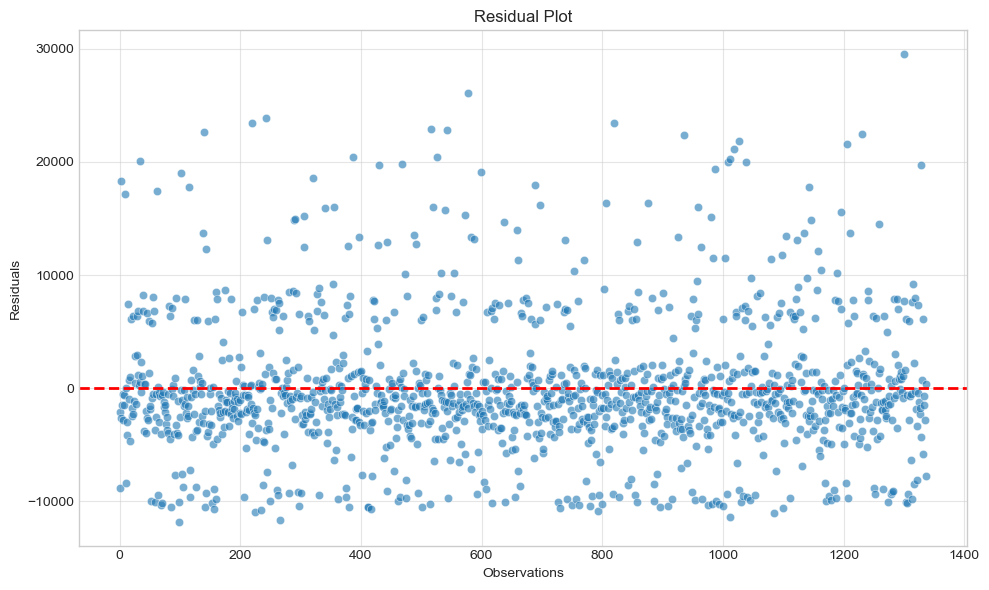

```python
plt.figure(figsize= (10,6))
sns.scatterplot(residuals, marker= 'o', alpha= 0.6)
plt.axhline(0, color= 'red', linestyle= '--', linewidth= 2)
plt.xlabel('Observations')
plt.ylabel('Residuals')
plt.title('Residual Plot')
plt.grid(True, alpha= 0.5)
plt.tight_layout()
plt.show()
```

(d) Use a stepwise model selection procedure of your choice to obtain a "best" fit model. Is the model different from the full model you fit in part (b)? If yes, how so?

**3D)** This model is different than the previous model because it only has 3 parameters and the coefficient values are different. Notably, the p-values are the same and still showing a statistical significance because of the small p-value = 0.00.

```python
X_sw = dummy_df[['age', 'bmi', 'children', 'sex_male', 'smoker_yes']]
y_sw = dummy_df['charges']
```

```python
#stepwise regression
sfs_sw = SequentialFeatureSelector(LinearRegression(),
             k_features= 3,
             forward= False,
             scoring= 'r2',
             cv= None)
selected_features = sfs_sw.fit(X_sw, y_sw)
```

```python
selected = list(selected_features.k_feature_names_)
print(selected)
```

```
['age', 'bmi', 'smoker_yes']
```

```python
X_best = sm.add_constant(dummy_df[selected])
best_model = sm.OLS(y_sw, X_best).fit()
print(best_model.summary())
```

```
                            OLS Regression Results
==============================================================================
Dep. Variable:                charges   R-squared:                       0.747
Model:                            OLS   Adj. R-squared:                  0.747
Method:                 Least Squares   F-statistic:                     1316.
Date:                Sun, 30 Nov 2025   Prob (F-statistic):               0.00
Time:                        22:31:18   Log-Likelihood:                -13557.
No. Observations:                1338   AIC:                         2.712e+04
Df Residuals:                    1334   BIC:                         2.714e+04
Df Model:                           3
Covariance Type:            nonrobust
==============================================================================
                 coef    std err          t      P>|t|      [0.025      0.975]
------------------------------------------------------------------------------
const      -1.168e+04    937.569    -12.454      0.000   -1.35e+04   -9837.561
age          259.5475     11.934     21.748      0.000     236.136     282.959
bmi          322.6151     27.487     11.737      0.000     268.692     376.538
smoker_yes  2.382e+04    412.867     57.703      0.000     2.3e+04    2.46e+04
==============================================================================
Omnibus:                      299.709   Durbin-Watson:                   2.077
Prob(Omnibus):                  0.000   Jarque-Bera (JB):              710.137
Skew:                           1.213   Prob(JB):                    6.25e-155
Kurtosis:                       5.618   Cond. No.                         289.
==============================================================================

Notes:
[1] Standard Errors assume that the covariance matrix of the errors is correctly specified.
```

EXTRA CREDIT (Max point: 2) : Fit a regression tree using the same covariates in your "best" fit model from part (d). Use cross validation to select the "best" tree. Compare the models from part (d) and (f) based on their performance. Which do you prefer? Be sure to justify your preference.

### Problem 4

Points: 20

The Wisconsin Breast Cancer dataset is available on the [UCI Machine Learning Repository](https://archive.ics.uci.edu/dataset/15/breast+cancer+wisconsin+original). Our goal in this problem will be to predict whether observations (i.e. tumors) are malignant or benign. We will use the original dataset in this problem.

(a) Obtain the data and load it into your programming environment by pulling it directly from the web (links provided below). (Do **not** download it and import it from a CSV file.) Give a brief description of the data.

**4A)** After importing the data directly from the website and inspecting it, I can see that the data is in measurements from ranges 1-10 that is used to give information on either size, shape, and other information. Whether the tumor is benign or malignant is the only classification that is not in the range of 1-10, but rather 2 (for begnin) and 4 (malignant). This is confirmed also on the website under the variable information.

```python
#Web location of data file
location = "http://archive.ics.uci.edu/ml/machine-learning-databases/"
dataframe = "breast-cancer-wisconsin/breast-cancer-wisconsin.data"
```

```python
#This code is directly copied from the website provided above from the import in python & import dataset into your code minus the last 2 print lines
from ucimlrepo import fetch_ucirepo

# fetch dataset
breast_cancer_wisconsin_original = fetch_ucirepo(id=15)

# data (as pandas dataframes)
X = breast_cancer_wisconsin_original.data.features
y = breast_cancer_wisconsin_original.data.targets
```

```python
X
```

|  | Clump_thickness | Uniformity_of_cell_size | Uniformity_of_cell_shape | Marginal_adhesion | Single_epithelial_cell_size | Bare_nuclei | Bland_chromatin | Normal_nucleoli | Mitoses |
| --- | --- | --- | --- | --- | --- | --- | --- | --- | --- |
| 0 | 5 | 1 | 1 | 1 | 2 | 1.0 | 3 | 1 | 1 |
| 1 | 5 | 4 | 4 | 5 | 7 | 10.0 | 3 | 2 | 1 |
| 2 | 3 | 1 | 1 | 1 | 2 | 2.0 | 3 | 1 | 1 |
| 3 | 6 | 8 | 8 | 1 | 3 | 4.0 | 3 | 7 | 1 |
| 4 | 4 | 1 | 1 | 3 | 2 | 1.0 | 3 | 1 | 1 |
| ... | ... | ... | ... | ... | ... | ... | ... | ... | ... |
| 694 | 3 | 1 | 1 | 1 | 3 | 2.0 | 1 | 1 | 1 |
| 695 | 2 | 1 | 1 | 1 | 2 | 1.0 | 1 | 1 | 1 |
| 696 | 5 | 10 | 10 | 3 | 7 | 3.0 | 8 | 10 | 2 |
| 697 | 4 | 8 | 6 | 4 | 3 | 4.0 | 10 | 6 | 1 |
| 698 | 4 | 8 | 8 | 5 | 4 | 5.0 | 10 | 4 | 1 |

699 rows × 9 columns

```python
y
```

|  | Class |
| --- | --- |
| 0 | 2 |
| 1 | 2 |
| 2 | 2 |
| 3 | 2 |
| 4 | 2 |
| ... | ... |
| 694 | 2 |
| 695 | 2 |
| 696 | 4 |
| 697 | 4 |
| 698 | 4 |

699 rows × 1 columns

```python
#have my tables but going to join them to one
breast_cancer_df = pd.concat([X, y], axis= 1)
```

```python
breast_cancer_df.shape
```

```
(699, 10)
```

```python
#inspecting my new table
breast_cancer_df.head(10)
```

|  | Clump_thickness | Uniformity_of_cell_size | Uniformity_of_cell_shape | Marginal_adhesion | Single_epithelial_cell_size | Bare_nuclei | Bland_chromatin | Normal_nucleoli | Mitoses | Class |
| --- | --- | --- | --- | --- | --- | --- | --- | --- | --- | --- |
| 0 | 5 | 1 | 1 | 1 | 2 | 1.0 | 3 | 1 | 1 | 2 |
| 1 | 5 | 4 | 4 | 5 | 7 | 10.0 | 3 | 2 | 1 | 2 |
| 2 | 3 | 1 | 1 | 1 | 2 | 2.0 | 3 | 1 | 1 | 2 |
| 3 | 6 | 8 | 8 | 1 | 3 | 4.0 | 3 | 7 | 1 | 2 |
| 4 | 4 | 1 | 1 | 3 | 2 | 1.0 | 3 | 1 | 1 | 2 |
| 5 | 8 | 10 | 10 | 8 | 7 | 10.0 | 9 | 7 | 1 | 4 |
| 6 | 1 | 1 | 1 | 1 | 2 | 10.0 | 3 | 1 | 1 | 2 |
| 7 | 2 | 1 | 2 | 1 | 2 | 1.0 | 3 | 1 | 1 | 2 |
| 8 | 2 | 1 | 1 | 1 | 2 | 1.0 | 1 | 1 | 5 | 2 |
| 9 | 4 | 2 | 1 | 1 | 2 | 1.0 | 2 | 1 | 1 | 2 |

```python
breast_cancer_df.tail(10)
```

|  | Clump_thickness | Uniformity_of_cell_size | Uniformity_of_cell_shape | Marginal_adhesion | Single_epithelial_cell_size | Bare_nuclei | Bland_chromatin | Normal_nucleoli | Mitoses | Class |
| --- | --- | --- | --- | --- | --- | --- | --- | --- | --- | --- |
| 689 | 1 | 1 | 1 | 1 | 2 | 1.0 | 1 | 1 | 8 | 2 |
| 690 | 1 | 1 | 1 | 3 | 2 | 1.0 | 1 | 1 | 1 | 2 |
| 691 | 5 | 10 | 10 | 5 | 4 | 5.0 | 4 | 4 | 1 | 4 |
| 692 | 3 | 1 | 1 | 1 | 2 | 1.0 | 1 | 1 | 1 | 2 |
| 693 | 3 | 1 | 1 | 1 | 2 | 1.0 | 2 | 1 | 2 | 2 |
| 694 | 3 | 1 | 1 | 1 | 3 | 2.0 | 1 | 1 | 1 | 2 |
| 695 | 2 | 1 | 1 | 1 | 2 | 1.0 | 1 | 1 | 1 | 2 |
| 696 | 5 | 10 | 10 | 3 | 7 | 3.0 | 8 | 10 | 2 | 4 |
| 697 | 4 | 8 | 6 | 4 | 3 | 4.0 | 10 | 6 | 1 | 4 |
| 698 | 4 | 8 | 8 | 5 | 4 | 5.0 | 10 | 4 | 1 | 4 |

(b) Investigate the data, ensuring that each variable is properly named and cast as the correct data type. Discuss any missing data.

**4B)** In our data, only one variable is missing values which is the Bare_nuclei, missing 16 values. This variable also is not the right data type. Inspecting the data types using the info function, all of our data are in integers and are supposed to be referencing the website except for the Bare_nuclei populating as a float. The rest of our data seems to be complete and non-erroneous.

```python
breast_cancer_df.describe()
```

|  | Clump_thickness | Uniformity_of_cell_size | Uniformity_of_cell_shape | Marginal_adhesion | Single_epithelial_cell_size | Bare_nuclei | Bland_chromatin | Normal_nucleoli | Mitoses | Class |
| --- | --- | --- | --- | --- | --- | --- | --- | --- | --- | --- |
| count | 699.000000 | 699.000000 | 699.000000 | 699.000000 | 699.000000 | 683.000000 | 699.000000 | 699.000000 | 699.000000 | 699.000000 |
| mean | 4.417740 | 3.134478 | 3.207439 | 2.806867 | 3.216023 | 3.544656 | 3.437768 | 2.866953 | 1.589413 | 2.689557 |
| std | 2.815741 | 3.051459 | 2.971913 | 2.855379 | 2.214300 | 3.643857 | 2.438364 | 3.053634 | 1.715078 | 0.951273 |
| min | 1.000000 | 1.000000 | 1.000000 | 1.000000 | 1.000000 | 1.000000 | 1.000000 | 1.000000 | 1.000000 | 2.000000 |
| 25% | 2.000000 | 1.000000 | 1.000000 | 1.000000 | 2.000000 | 1.000000 | 2.000000 | 1.000000 | 1.000000 | 2.000000 |
| 50% | 4.000000 | 1.000000 | 1.000000 | 1.000000 | 2.000000 | 1.000000 | 3.000000 | 1.000000 | 1.000000 | 2.000000 |
| 75% | 6.000000 | 5.000000 | 5.000000 | 4.000000 | 4.000000 | 6.000000 | 5.000000 | 4.000000 | 1.000000 | 4.000000 |
| max | 10.000000 | 10.000000 | 10.000000 | 10.000000 | 10.000000 | 10.000000 | 10.000000 | 10.000000 | 10.000000 | 4.000000 |

```python
breast_cancer_df.info()
```

```
<class 'pandas.core.frame.DataFrame'>
RangeIndex: 699 entries, 0 to 698
Data columns (total 10 columns):
 #   Column                       Non-Null Count  Dtype
---  ------                       --------------  -----
 0   Clump_thickness              699 non-null    int64
 1   Uniformity_of_cell_size      699 non-null    int64
 2   Uniformity_of_cell_shape     699 non-null    int64
 3   Marginal_adhesion            699 non-null    int64
 4   Single_epithelial_cell_size  699 non-null    int64
 5   Bare_nuclei                  683 non-null    float64
 6   Bland_chromatin              699 non-null    int64
 7   Normal_nucleoli              699 non-null    int64
 8   Mitoses                      699 non-null    int64
 9   Class                        699 non-null    int64
dtypes: float64(1), int64(9)
memory usage: 54.7 KB
```

```python
#inspecting all null values
breast_cancer_df[breast_cancer_df['Bare_nuclei'].isnull()]
```

|  | Clump_thickness | Uniformity_of_cell_size | Uniformity_of_cell_shape | Marginal_adhesion | Single_epithelial_cell_size | Bare_nuclei | Bland_chromatin | Normal_nucleoli | Mitoses | Class |
| --- | --- | --- | --- | --- | --- | --- | --- | --- | --- | --- |
| 23 | 8 | 4 | 5 | 1 | 2 | NaN | 7 | 3 | 1 | 4 |
| 40 | 6 | 6 | 6 | 9 | 6 | NaN | 7 | 8 | 1 | 2 |
| 139 | 1 | 1 | 1 | 1 | 1 | NaN | 2 | 1 | 1 | 2 |
| 145 | 1 | 1 | 3 | 1 | 2 | NaN | 2 | 1 | 1 | 2 |
| 158 | 1 | 1 | 2 | 1 | 3 | NaN | 1 | 1 | 1 | 2 |
| 164 | 5 | 1 | 1 | 1 | 2 | NaN | 3 | 1 | 1 | 2 |
| 235 | 3 | 1 | 4 | 1 | 2 | NaN | 3 | 1 | 1 | 2 |
| 249 | 3 | 1 | 1 | 1 | 2 | NaN | 3 | 1 | 1 | 2 |
| 275 | 3 | 1 | 3 | 1 | 2 | NaN | 2 | 1 | 1 | 2 |
| 292 | 8 | 8 | 8 | 1 | 2 | NaN | 6 | 10 | 1 | 4 |
| 294 | 1 | 1 | 1 | 1 | 2 | NaN | 2 | 1 | 1 | 2 |
| 297 | 5 | 4 | 3 | 1 | 2 | NaN | 2 | 3 | 1 | 2 |
| 315 | 4 | 6 | 5 | 6 | 7 | NaN | 4 | 9 | 1 | 2 |
| 321 | 3 | 1 | 1 | 1 | 2 | NaN | 3 | 1 | 1 | 2 |
| 411 | 1 | 1 | 1 | 1 | 1 | NaN | 2 | 1 | 1 | 2 |
| 617 | 1 | 1 | 1 | 1 | 1 | NaN | 1 | 1 | 1 | 2 |

```python
#fixing the dtype from float to int but also dropping the null values
bc_df = breast_cancer_df.copy()
bc_df = bc_df.dropna(subset= ['Bare_nuclei'])
bc_df['Bare_nuclei'] = bc_df['Bare_nuclei'].astype(int)
```

(c) Split the data into a training and test set such that a random 70% of the observations are in the training set.

```python
from sklearn.model_selection import train_test_split
from sklearn.metrics import classification_report, confusion_matrix
```

```python
X = bc_df.drop('Class', axis= 1)
y = bc_df['Class']
```

```python
#setting a testing data of 30% so training is 70%
X_train, X_test, y_train, y_test = train_test_split(
    X, y,
    test_size= 0.3,
    random_state= 42)
```

(d) Fit a ML model to predict whether tissue samples are malignant or benign. Then use your model to classify cases in your test set, which is the remaining 30% of the all the observations. Compute and discuss the resulting confusion matrix. Be sure to address which of the errors that are identified you consider most problematic in this context.

**4D**) In ps8, I used this website as a reference in understanding my confusion matrix (https://www.geeksforgeeks.org/machine-learning/confusion-matrix-machine-learning/) in which I used as a source in better understanding my confusion matrix results in which I used again along with the sklearn documentation from here: https://scikit-learn.org/stable/modules/generated/sklearn.metrics.confusion_matrix.html. After having split the data so that 70% of the observations were in the training set, the resulting confusion matrix predicted 125 correctly begnign and only 2 false positives; only 2 were predicted malignant but were actually begnign. The model predicted 7 false negatives and 71 true positives. The 7 false negatives would be the errors that would be considered the most problematic in this context because 7 tumors were predicted to be begnign but were actually malignant. This is problematic because this is fundamentally a life or death situation dealing with breast cancer. Classifying someones tumor to be non-cancerous when it actually is, not only causes physical harm in not getting them the treatment that they need but emotional and pyschological harm as well.

```python
model_bc = LogisticRegression()
model_bc.fit(X_train, y_train)
```

```
LogisticRegression()
```

```python
#confusion matrix
y_pred = model_bc.predict(X_test)
cm_log = confusion_matrix(y_test, y_pred)
print(cm_log)
```

```
[[125   2]
 [  7  71]]
```

```python
#classification report
print(classification_report(y_test, y_pred,
                      target_names= ['Benign', 'Malignant']))
```

```
              precision    recall  f1-score   support

      Benign       0.95      0.98      0.97       127
   Malignant       0.97      0.91      0.94        78

    accuracy                           0.96       205
   macro avg       0.96      0.95      0.95       205
weighted avg       0.96      0.96      0.96       205
```

### Problem 5

Points: 10

Please answer the questions below by writing a short response.

(a) Describe three real-life applications in which **classification** might be useful. Describe the response, as well as the predictors. Is the goal in each application inference or predictions? Explain your answer.

**5A**) Referencing the class textbook ISLP_Python (pg. 135 & 136), we learned why using classification is important; we sometimes need to make predictions for responses that are classified as qualitative rather than quantitative. Three-real life applications that the textbook used was 1. A person arriving at the ER that is displaying a set of symptoms that could be one of three medical conditions. In this scenario the response variable would be the medical condition we are trying to pinpoint and the predictors would be the set of symptoms they are displaying. For this scenario, the goal for this application would be predition because we are trying to predict which medical condition the individual has based on a set of symptoms. 2. An online banking service trying to determine whether a transaction is fradulent or not based on IP address, past transaction histroy, etc. Similarly to the first scenario, this would also be a scenario where the goal is to predict because of the data the online banking service is able to use and see e.g., IP address, transaction history, etc. The response variable would be if the transaction is fradulent and the predictors would be the data that the banking service has. 3. The last example used was on a basis of DNA sequence data on patients that have and do not have a disease and a biologist is trying to see which DNA mutations are disease-causing and which ones are not. This example is a little different than the previous two because in this scenario the biologist is interested in more than just if someone has the disease or not so the goal in this application would be inference. In this application, the response variable is whether the DNA mutation is disease-causing and the predictors would be the DNA sequence data from the patients.

b) Describe three real-life applications in which **regression** might be useful. Describe the response, as well as the predictors. Is the goal in each application inference or predictions? Explain your answer.

**5B)** Three real-life applications in which regression might be useful is like the advertising budget and sales example in the ISLP_Python textbook, businesses can use regression to forecast sales. The goal in this example would be for prediction and the response variable would be sales and the predictor would be the advertising spend. Another example the text used is to predict credit balances using variables like income and student status. In this scenario, the response variable would be the credit card balance and the predictors are the income and student status, the goal in this application would also be prediction. Lastly, referencing an example from the course lab homeworks we could use regression to predict which individuals would be at high risk for heart disease. The response variable would be heart disease or not and the predictors would be the demographic information of the individuals or other factors like lifestyle and family history this could be prediction or inference. These are three real-life applications where regression is used in everday life and can be very insightful and valuable information.

(c) What are the advantages and disadvantages of a very flexible (versus a less flexible) approach for regression or classification? Under what circumstances might a more flexible approach be preferred to a less flexible approach? When might a less flexible approach be preferred?

**5C)** Some advantages of a very flexible approach is that it can capture complex relationships and since they are very flexible they are also adaptable. According to our ISLP (pg. 33) text book, more flexible methods also result in less bias. A disadvantage to that is there runs a risk of overfitting the data since the data is complex. An advantage to a less flexible approach is that they are more simple meaning less complex so they are easier to understand and there is a lower risk of overfitting the data, but runs a higher risk of bias which is a disadvantage. (Additional Reference: https://www.geeksforgeeks.org/machine-learning/underfitting-and-overfitting-in-machine-learning/)

### Problem 6

Points: 10

Suppose we have a dataset with five predictors, $X_1 =$ GPA, $X_2 =$ IQ, $X_3 =$ Gender (1 for Female, and 0 for Male), $X_4 =$ Interaction between GPA and IQ, and $X_5 =$ Interaction between GPA and Gender. Note: the data here is limited as gender was collected as a binary variable.

The response is starting salary after graduation (in thousands of dollars). Suppose we use least squares to fit the model and get $\hat{\beta}_0=50, \hat{\beta}_1=20, \hat{\beta}_2=0.07, \hat{\beta}_3=35, \hat{\beta}_4=0.01$, and $\hat{\beta}_5=-10$.

(a) Which answer is correct and why? [single choice question]

i. For a fixed value of IQ and GPA, males earn more on average than females.

ii. For a fixed value of IQ and GPA, females earn more on average than males.

iii. For a fixed value of IQ and GPA, males earn more on average than females provided that the GPA is high enough.

iv. For a fixed value of IQ and GPA, females earn more on average than males provided that the GPA is high enough.

**6A)** iii is correct because of the difference. If the GPA is low, females earn more, but if it is high enough then males earn more on average.

(b) Wite down the least square function and then predict the salary of a female with IQ of 110 and a GPA of 4.0.

```python
#function for least squares to predict salary
def salary_prediction(gpa, iq, gender):
    beta_0 = 50
    beta_1 = 20
    beta_2 = 0.07
    beta_3 = 35
    beta_4 = 0.01
    beta_5 = -10

    gpa_iq = gpa * iq
    gpa_gender = gpa * gender

    salary = (beta_0 +
    beta_1 * gpa +
    beta_2 * iq +
    beta_3 * gender +
    beta_4 * gpa_iq +
    beta_5 * gpa_gender)

    return salary
```

```python
#female prediction
female_prd = salary_prediction(gpa= 4.0, iq= 110, gender= 1)
print(female_prd)
```

```
137.1
```

(c) True or false: Since the coefficient for the GPA/IQ interaction term is very small, there is little evidence of an interaction effect. Justify your answer.

**6C)** True

### Problem 7 - Extra Credit

Points: Max. 4

Suppose that $X_1, \ldots X_n$ form a random sample from a Poisson distribution for which the mean $\theta$ is unknown, $(\theta>0)$.

(a) Determine the MLE of $\theta$, assuming that at least one of the observed values is different from 0. Show your work.

(b) Show that the MLE of $\theta$ does not exists if every observed value is 0.

### Problem 8 - Extra Credit

Points: Max. 4

In this extra credit problem, you'll build a simple web scraper to collect and process text data. You'll write the code necessary to scrape lyrics for a desired artist. Your code should be structured such that one can easily execute your scraping functions for a given artist. There are three deliverables for this assignment:

1. A set of functions necessary for scraping the lyrics of a specific artist.
2. An example implementation of using your functions.
3. A file of example output from your notebook implementation.

The specific approach that you take to structuring your code is up to you, but the final output .csv data should have the following columns (each row is a song from an artist that you choose):

- Column 1: artist
- Column 2: album
- Column 3: song title
- Column 4: URL of song lyrics
- Column 5: song lyrics (all of the lyrics in one column)
- Column 6: number of words in the song

**Data Scraping:** The actual scraping of data should be supported by separate functions that accomplish these tasks:

1. Given an artist, identify all of their albums, songs, and links to songs.
2. Given a set of song links (from step 1), collect the lyrics to each song and store them in a data frame.

In order to do this, you'll need to understand the structure of your lyrics site. The site you use is up to you, but all of this information should be available on lyrics.com.

**Data Processing:**

Once you've scraped the data, you'll need to do some simple text analysis to generate your columns of interest (feel free to do this as part of step 2 above, the collection of lyrics for each song or as a separate step entirely). Recall you are aiming to count the number of words in each song.

**Example Implementation:**

You should demonstrate the implementation of your data scraping functions with a particular artist. To do this you can simply set an artist, and run your scraping functions. The way in which you choose to structure your functions is up to you, as long as the implementation and documentation is clear. One way in which we'll test this is changing the artist to confirm the flexibility of your implementation.

It may look something like this:

```python
# NOTE THIS CODE WILL NOT RUN
# UNTIL YOU WRITE YOUR WEB SCRAPING FUNCTIONS

# Get songs
artist = 'Adele'
all_songs = get_songs(artist)

# Get lyrics -- internally, you may want to another function in your library, such as get_lyrics()
lyrics = get_all_lyrics(songs)

# Save data -- this function should identify the name of the artist and use it in the .csv file it saves
save_lyrics(lyrics)
```

(a) Write a function to get all the songs of a particular artist.

(b) Write a function to get all the lyrics for a particular song. You may also want to write a function to get all the lyrics for a list of songs.

(c) Choose a particular artist. Get all their songs. Get all the lyrics for their songs. Process the data so that you end up with a nice, tidy data structure as described in the instructions (i.e. the six columns listed above). Write out the data to a CSV file.

(d) Produce one visualization of the data to aids in understanding the distribution of words in songs for a particular artist. Comment on what you find.